## Exercise 1 & 2: Setup and Data Split

We start by loading the necessary libraries and the SPY dataset from Yahoo Finance. The data is then split into 80% for training and 20% for testing.

```r
suppressPackageStartupMessages({
  library(quantmod)
  library(dplyr)
  library(ggplot2)
  library(keras)
  library(tibble)
})

set.seed(42)

# Load Data
getSymbols("SPY", src = "yahoo", from = "2015-01-01", auto.assign = TRUE)
```

```
## [1] "SPY"
```

```r
spy_returns_xts <- dailyReturn(Ad(SPY)) * 100
returns <- as.numeric(spy_returns_xts)

# Data Split
train_size <- floor(0.8 * length(returns))
train_returns <- returns[1:train_size]
test_returns <- returns[(train_size + 1):length(returns)]

cat("Training data size:", length(train_returns), "\n")
```

```
## Training data size: 2112
```

```r
cat("Test data size:", length(test_returns), "\n")
```

```
## Test data size: 528
```

## Environment and Replay Buffer

We reuse the environment and replay buffer functions from the previous tasks.

```r
# Environment Functions
make_state <- function(t, pos, returns_data, window_size = 10) {
  state_vector <- returns_data[(t - window_size + 1):t]
  c(state_vector, pos)
}

env_reset <- function(returns_data) {
  list(t = 10, pos = 0, equity = 1, done = FALSE, returns_data = returns_data)
}

env_step <- function(env, action, transaction_cost = 0.0005) {
  t <- env$t
  pos <- env$pos
  equity <- env$equity
  returns_data <- env$returns_data

  if (t >= length(returns_data) - 1) {
    return(list(next_env = env, reward = 0, obs = rep(0, 11), done = TRUE))
  }

  r_t1 <- returns_data[t + 1] / 100
  reward <- 0

  if (action == 1 && pos == 0) { # Buy
    reward <- r_t1 - transaction_cost
    pos <- 1
  } else if (action == 0 && pos == 1) { # Sell
    reward <- -transaction_cost
    pos <- 0
  } else if (action == 1 && pos == 1) { # Hold
    reward <- r_t1
  } # if action is 0 and pos is 0, reward is 0

  equity <- equity * (1 + reward)
  t <- t + 1
  done <- (t >= length(returns_data) - 1)

  next_env <- list(t = t, pos = pos, equity = equity, done = done, returns_data = returns_data)
  obs <- make_state(t, pos, returns_data)

  list(next_env = next_env, reward = reward, obs = obs, done = done)
}

# Replay Buffer
replay_buffer <- new.env()
buffer_capacity <- 5000
state_size <- 11

replay_buffer$s  <- matrix(0, nrow = buffer_capacity, ncol = state_size)
replay_buffer$a  <- integer(buffer_capacity)
replay_buffer$r  <- numeric(buffer_capacity)
replay_buffer$s2 <- matrix(0, nrow = buffer_capacity, ncol = state_size)
replay_buffer$done <- logical(buffer_capacity)
replay_buffer$idx <- 1
replay_buffer$is_full <- FALSE

store_transition <- function(buffer, s, a, r, s2, done) {
  idx <- buffer$idx
  buffer$s[idx, ] <- s
  buffer$a[idx] <- a
  buffer$r[idx] <- r
  buffer$s2[idx, ] <- s2
  buffer$done[idx] <- done

  buffer$idx <- buffer$idx + 1
  if (buffer$idx > buffer_capacity) {
    buffer$idx <- 1
    buffer$is_full <- TRUE
  }
}

sample_batch <- function(buffer, n) {
  max_index <- if (buffer$is_full) buffer_capacity else (buffer$idx - 1)
  sampled_idx <- sample(1:max_index, size = n, replace = FALSE)

  list(
    s = buffer$s[sampled_idx, , drop = FALSE],
    a = buffer$a[sampled_idx],
    r = buffer$r[sampled_idx],
    s2 = buffer$s2[sampled_idx, , drop = FALSE],
    done = buffer$done[sampled_idx]
  )
}
```

## Exercise 3: Network Factory

A function `build_qnet` is created to instantiate the Q-network, allowing us to create both an online and a target network with the same architecture.

```r
build_qnet <- function(input_nodes = 11, output_nodes = 2, hidden_units = 32) {
  model <- keras_model_sequential() %>%
    layer_dense(units = hidden_units, activation = "relu", input_shape = c(input_nodes)) %>%
    layer_dense(units = output_nodes, activation = "linear")
  return(model)
}
```

## Exercise 4: Epsilon-Greedy Function

The `epsilon_decay` function calculates the current epsilon value, which decays exponentially over episodes.

```r
epsilon_decay <- function(ep, start = 1.0, final = 0.01, decay_rate = 0.01) {
  final + (start - final) * exp(-decay_rate * ep)
}
```

## Exercise 5: Hyperparameters

Sensible hyperparameters are chosen for the training process.

```r
gamma <- 0.99 # Discount factor for future rewards. A high value signifies the agent values future rewards almost as much as immediate ones.
learning_rate <- 0.001 # Step size for gradient descent. A small value ensures stable learning.
replay_capacity <- 5000 # Max size of the replay buffer. Large enough to store diverse experiences.
warmup_size <- 1000 # Steps before training starts. Ensures the buffer has enough random samples.
max_steps_ep <- 200 # Max steps per episode. Prevents episodes from running too long.
epsilon_start <- 1.0 # Initial epsilon. Starts with full exploration.
epsilon_final <- 0.01 # Final epsilon. Ends with mostly exploitation.
epsilon_decay_rate <- 0.01 # Rate of epsilon decay. Controls the speed of transition from exploration to exploitation.
batch_size <- 32 # Number of samples per training batch. A standard size for stable updates.
```

## Exercise 6: Training Loop

The main training loop where the agent interacts with the environment and learns.

```r
online_net <- build_qnet()
target_net <- build_qnet()
target_net %>% set_weights(online_net %>% get_weights())

online_net %>% compile(
  optimizer = optimizer_adam(learning_rate = learning_rate),
  loss = "mse"
)

total_episodes <- 10
episode_log <- list()

for (ep in 1:total_episodes) {
  env <- env_reset(train_returns)
  state <- make_state(env$t, env$pos, env$returns_data)

  episode_reward <- 0
  episode_equity <- c(env$equity)

  for (step in 1:max_steps_ep) {
    # Epsilon-greedy action selection
    epsilon <- epsilon_decay(ep, start = epsilon_start, final = epsilon_final, decay_rate = epsilon_decay_rate)
    if (runif(1) < epsilon) {
      action <- sample(0:1, 1) # Explore
    } else {
      q_values <- online_net %>% predict(t(state), verbose = 0)
      action <- which.max(q_values) - 1 # Exploit (0 or 1)
    }

    # Environment step
    step_result <- env_step(env, action)
    next_state <- step_result$obs
    reward <- step_result$reward
    done <- step_result$done

    store_transition(replay_buffer, state, action, reward, next_state, done)

    state <- next_state
    env <- step_result$next_env
    episode_reward <- episode_reward + reward
    episode_equity <- c(episode_equity, env$equity)

    # Training
    if (replay_buffer$idx > warmup_size) {
      batch <- sample_batch(replay_buffer, batch_size)

      q_next <- target_net %>% predict(batch$s2, verbose = 0)
      q_next_max <- apply(q_next, 1, max)

      target_q <- batch$r + gamma * q_next_max * (1 - batch$done)

      current_q <- online_net %>% predict(batch$s, verbose = 0)

      for (i in 1:batch_size) {
        current_q[i, batch$a[i] + 1] <- target_q[i]
      }

      train_on_batch(online_net, batch$s, current_q)
    }

    if (done) break
  }

  # Update target network
  if (ep %% 10 == 0) {
    target_net %>% set_weights(online_net %>% get_weights())
  }

  episode_log[[ep]] <- list(reward = episode_reward, equity_hist = episode_equity)
  cat(sprintf("Episode: %d, Total Reward: %.4f, Final Equity: %.4f\n", ep, episode_reward, tail(episode_equity, 1)))
}
```

```
## Episode: 1, Total Reward: -0.0335, Final Equity: 0.9625
## Episode: 2, Total Reward: -0.0398, Final Equity: 0.9552
## Episode: 3, Total Reward: 0.0304, Final Equity: 1.0249
## Episode: 4, Total Reward: -0.0230, Final Equity: 0.9720
## Episode: 5, Total Reward: -0.1569, Final Equity: 0.8506
## Episode: 6, Total Reward: 0.1330, Final Equity: 1.1371
## Episode: 7, Total Reward: 0.1070, Final Equity: 1.1073
## Episode: 8, Total Reward: 0.0592, Final Equity: 1.0573
## Episode: 9, Total Reward: -0.0067, Final Equity: 0.9900
## Episode: 10, Total Reward: -0.0642, Final Equity: 0.9341
```

## Exercise 7: Visual Inspection

We evaluate the trained agent’s performance against a simple buy-and-hold strategy on the training data.

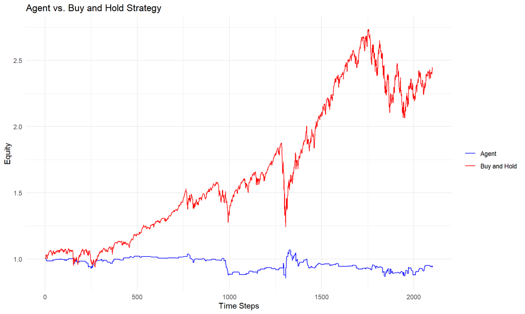

```r
# Run an episode with epsilon = 0 on training data
env_eval <- env_reset(train_returns)
state_eval <- make_state(env_eval$t, env_eval$pos, env_eval$returns_data)
agent_equity <- c(env_eval$equity)

while(!env_eval$done) {
  q_values <- online_net %>% predict(t(state_eval), verbose = 0)
  action <- which.max(q_values) - 1

  step_result <- env_step(env_eval, action)
  state_eval <- step_result$obs
  env_eval <- step_result$next_env
  agent_equity <- c(agent_equity, env_eval$equity)
}

# Buy and Hold Strategy
buy_and_hold_equity <- cumprod(1 + c(0, train_returns[11:length(train_returns)] / 100))

# Plotting
plot_df <- data.frame(
  Step = 1:length(agent_equity),
  Agent = agent_equity,
  BuyAndHold = buy_and_hold_equity[1:length(agent_equity)]
)

ggplot(plot_df, aes(x = Step)) +
  geom_line(aes(y = Agent, colour = "Agent")) +
  geom_line(aes(y = BuyAndHold, colour = "Buy and Hold")) +
  labs(title = "Agent vs. Buy and Hold Strategy", y = "Equity", x = "Time Steps") +
  scale_colour_manual("", values = c("Agent"="blue", "Buy and Hold"="red")) +
  theme_minimal()
```

## Exercise 8: Discussion

Trade costs directly reduce the reward for buying or selling, making the agent more hesitant to trade. This can lead to a strategy that holds positions for longer to avoid incurring frequent costs. To improve the result, one could:

- **Optimize transaction costs:** Find a broker with lower fees.
- **Improve the reward function:** Add a term that penalizes frequent trading to encourage longer-term holding.
- **Use a more sophisticated model:** A more complex model might be able to better identify profitable trades that justify the transaction costs.

## Reflection Questions

**Explain “bootstrapping” in the Bellman update.**

Bootstrapping, in the context of the Bellman equation, refers to the process of updating a value estimate based on other value estimates. In our Q-learning implementation, the target Q-value for a state-action pair is calculated using the estimated Q-values of the *next* state. We are using an existing estimate (the Q-value of the next state) to improve the current estimate, which is the essence of bootstrapping.

**Why is a separate target network more stable than using the online weights directly as target?**

A separate target network provides a stable target for the online network to learn from. If we were to use the online network to calculate the target values, the target would change with every weight update. This creates a moving-target problem, making the training process unstable. By using a fixed (or slowly updating) target network, we provide a consistent objective for the online network, which leads to more stable and reliable learning.

**How would you extend the action space to short selling?**

To extend the action space to include short selling, we would need to add a third action, for example, `action = 2` for “short”. The environment’s `env_step` function would need to be modified to handle this new action. This would involve:

- When the agent chooses to short, the reward would be the *negative* of the next period’s return, minus transaction costs.
- The agent’s position would need to be updated to reflect the short position (e.g., `pos = -1`).
- The logic for handling existing positions would also need to be updated to account for being in a short position.

The Q-network’s output layer would also need to be changed to have three nodes, one for each action (long, flat, short).